# RentTheRunway1

## Problem statement

Based on the given users and items data of an e-commerce company, segment the similar user and items into suitable clusters. Analyze the clusters and provide your insights to help the organization promote their business.

## Business Context:

Customersegmentation is one of the most important marketing tools at your disposal, because it can help a business to better understand its target audience. This is because it groups customers based on common characteristics.

● Segmentationcanbebasedonthecustomer’shabitsandlifestyle,in particular, their buying habits. Different age groups, for example, tend to spend their money in different ways, so brands need to be aware of who exactly is buying their product.

● Segmentationalsofocusesmoreonthepersonalityoftheconsumer, including their opinions, interests, reviews, and rating. Breaking down a large customer base into more manageable clusters, making it easier to identify your target audience and launch campaigns and promote the business to the most relevant people

## Dataset Description:

The dataset contains measurements of clothing fit from RentTheRunway. RentTheRunWay is a unique platform that allows women to rent clothes for various occasions. The collected data is of several categories. This dataset contains self-reported fit feedback from customers as well as other side information like reviews, ratings, product categories, catalog sizes, customers’ measurements (etc.)

1. user_id: a unique id for the customer
2. item_id: unique product id
3. weight: weight measurement of customer
4. rented for: purpose clothing was rented for
5. body type: body type of customer
6. review_text: review given by the customer
7. size: the standardized size of the product
8. rating: rating for the product
9. age: age of the customer
10. category: the category of the product
11. bust size: bust measurement of customer
12. height: height of the customer
13. review_date: date when the review was written
14. fit: fit feedback

## PART 1: Import the required libraries and load the data

### 1. Load the required libraries and read the dataset

```python
import numpy as np
import pandas as pd
import matplotlib.pyplot as plt
import seaborn as sns
import sklearn
from sklearn.model_selection import train_test_split
from sklearn.preprocessing import StandardScaler

import warnings
warnings.filterwarnings('ignore')

from sklearn.preprocessing import LabelEncoder
from sklearn.decomposition import PCA
from sklearn.cluster import KMeans
from scipy.cluster.hierarchy import linkage, dendrogram, fcluster
from sklearn.cluster import AgglomerativeClustering
```

```python
df = pd.read_csv("./renttherunway-1.csv")
```

### 2. Check the first few samples, shape, info of the data and try to familiarize yourself with different features

```python
## Lets check first few samples of the data
df.head()
```

|  | Unnamed: 0 | fit | user_id | bust size | item_id | weight | rating | rented for | review_text | body type | review_summary | category | height | size | age | review_date |
| --- | --- | --- | --- | --- | --- | --- | --- | --- | --- | --- | --- | --- | --- | --- | --- | --- |
| 0 | 0 | fit | 420272 | 34d | 2260466 | 137lbs | 10.0 | vacation | An adorable romper! Belt and zipper were a lit... | hourglass | So many compliments! | romper | 5' 8" | 14 | 28.0 | April 20, 2016 |
| 1 | 1 | fit | 273551 | 34b | 153475 | 132lbs | 10.0 | other | I rented this dress for a photo shoot. The the... | straight & narrow | I felt so glamourous!!! | gown | 5' 6" | 12 | 36.0 | June 18, 2013 |
| 2 | 2 | fit | 360448 | NaN | 1063761 | NaN | 10.0 | party | This hugged in all the right places! It was a ... | NaN | It was a great time to celebrate the (almost) ... | sheath | 5' 4" | 4 | 116.0 | December 14, 2015 |
| 3 | 3 | fit | 909926 | 34c | 126335 | 135lbs | 8.0 | formal affair | I rented this for my company's black tie award... | pear | Dress arrived on time and in perfect condition. | dress | 5' 5" | 8 | 34.0 | February 12, 2014 |
| 4 | 4 | fit | 151944 | 34b | 616682 | 145lbs | 10.0 | wedding | I have always been petite in my upper body and... | athletic | Was in love with this dress !!! | gown | 5' 9" | 12 | 27.0 | September 26, 2016 |

```python
df.shape
```

```
(192544, 16)
```

```python
df.info()
```

```
<class 'pandas.core.frame.DataFrame'>
RangeIndex: 192544 entries, 0 to 192543
Data columns (total 16 columns):
 #   Column          Non-Null Count   Dtype
---  ------          --------------   -----
 0   Unnamed: 0      192544 non-null  int64
 1   fit             192544 non-null  object
 2   user_id         192544 non-null  int64
 3   bust size       174133 non-null  object
 4   item_id         192544 non-null  int64
 5   weight          162562 non-null  object
 6   rating          192462 non-null  float64
 7   rented for      192534 non-null  object
 8   review_text     192482 non-null  object
 9   body type       177907 non-null  object
 10  review_summary  192199 non-null  object
 11  category        192544 non-null  object
 12  height          191867 non-null  object
 13  size            192544 non-null  int64
 14  age             191584 non-null  float64
 15  review_date     192544 non-null  object
dtypes: float64(2), int64(4), object(10)
memory usage: 23.5+ MB
```

```python
df.describe()
```

|  | Unnamed: 0 | user_id | item_id | rating | size | age |
| --- | --- | --- | --- | --- | --- | --- |
| count | 192544.000000 | 192544.000000 | 1.925440e+05 | 192462.000000 | 192544.000000 | 191584.000000 |
| mean | 96271.500000 | 499494.100149 | 1.045684e+06 | 9.092371 | 12.245175 | 33.871017 |
| std | 55582.809453 | 289059.719328 | 8.053148e+05 | 1.430044 | 8.494877 | 8.058083 |
| min | 0.000000 | 9.000000 | 1.233730e+05 | 2.000000 | 0.000000 | 0.000000 |
| 25% | 48135.750000 | 250654.250000 | 1.950760e+05 | 8.000000 | 8.000000 | 29.000000 |
| 50% | 96271.500000 | 499419.000000 | 9.483960e+05 | 10.000000 | 12.000000 | 32.000000 |
| 75% | 144407.250000 | 750974.000000 | 1.678888e+06 | 10.000000 | 16.000000 | 37.000000 |
| max | 192543.000000 | 999997.000000 | 2.966087e+06 | 10.000000 | 58.000000 | 117.000000 |

```python
# Percentage of null values in grouped by column name in data

df.isnull().sum()/len(df) * 100
```

```
Unnamed: 0         0.000000
fit                0.000000
user_id            0.000000
bust size          9.561970
item_id            0.000000
weight            15.571506
rating             0.042588
rented for         0.005194
review_text        0.032200
body type          7.601899
review_summary     0.179180
category           0.000000
height             0.351608
size               0.000000
age                0.498587
review_date        0.000000
dtype: float64
```

## PART 2: Data cleansing and Exploratory data analysis

### 3. Check if there are any duplicate records in the dataset? If any, drop them

```python
len(df[df.duplicated()])
```

```
0
```

- There are no duplicate records in the dataset

### 4. Drop the columns which you think redundant for the analysis.(Hint: drop columns like ‘id’, ‘review’)

```python
df.columns
```

```
Index(['Unnamed: 0', 'fit', 'user_id', 'bust size', 'item_id', 'weight',
       'rating', 'rented for', 'review_text', 'body type', 'review_summary',
       'category', 'height', 'size', 'age', 'review_date'],
      dtype='object')
```

```python
df=df.drop(['Unnamed: 0', 'user_id', 'item_id', 'review_text', 'review_summary', 'review_date'],axis=1)
```

### 5. Check the column 'weight', Is there any presence of string data? If yes, remove the string data and convert to float. (Hint: 'weight' has the suffix as lbs)

```python
df['weight']
```

```
0         137lbs
1         132lbs
2            NaN
3         135lbs
4         145lbs
           ...
192539    140lbs
192540    100lbs
192541    135lbs
192542    165lbs
192543    155lbs
Name: weight, Length: 192544, dtype: object
```

```python
df['weight']=pd.to_numeric(df['weight'].str.replace('lbs',''))
```

```python
df['weight']
```

```
0         137.0
1         132.0
2           NaN
3         135.0
4         145.0
          ...
192539    140.0
192540    100.0
192541    135.0
192542    165.0
192543    155.0
Name: weight, Length: 192544, dtype: float64
```

### 6. Check the unique categories for the column 'rented for' and group 'party: cocktail' category with 'party'.

```python
df['rented for'].unique()
```

```
array(['vacation', 'other', 'party', 'formal affair', 'wedding', 'date',
       'everyday', 'work', nan, 'party: cocktail'], dtype=object)
```

```python
df['rented for'] = df['rented for'].str.replace('party: cocktail','party')
```

```python
df['rented for'].unique()
```

```
array(['vacation', 'other', 'party', 'formal affair', 'wedding', 'date',
       'everyday', 'work', nan], dtype=object)
```

### 7. The column 'height' is in feet with a quotation mark, Convert to inches with float datatype.

```python
df['height']
```

```
0         5' 8"
1         5' 6"
2         5' 4"
3         5' 5"
4         5' 9"
          ...
192539    5' 9"
192540    5' 1"
192541    5' 8"
192542    5' 6"
192543    5' 6"
Name: height, Length: 192544, dtype: object
```

```python
df["height"] = df.height.str.replace('"','')
df["height"] = (df.height.str.split("'").str[0].astype(float) * 12) + (
    df.height.str.split("'").str[1].astype(float)
)
df['height']
```

```
0         68.0
1         66.0
2         64.0
3         65.0
4         69.0
          ...
192539    69.0
192540    61.0
192541    68.0
192542    66.0
192543    66.0
Name: height, Length: 192544, dtype: float64
```

### 8. Check for missing values in each column of the dataset? If it exists, impute them with appropriate methods

```python
df.isnull().sum()/len(df) * 100
```

```
fit            0.000000
bust size      9.561970
weight        15.571506
rating         0.042588
rented for     0.005194
body type      7.601899
category       0.000000
height         0.351608
size           0.000000
age            0.498587
dtype: float64
```

```python
df.info()
```

```
<class 'pandas.core.frame.DataFrame'>
RangeIndex: 192544 entries, 0 to 192543
Data columns (total 10 columns):
 #   Column      Non-Null Count   Dtype
---  ------      --------------   -----
 0   fit         192544 non-null  object
 1   bust size   174133 non-null  object
 2   weight      162562 non-null  float64
 3   rating      192462 non-null  float64
 4   rented for  192534 non-null  object
 5   body type   177907 non-null  object
 6   category    192544 non-null  object
 7   height      191867 non-null  float64
 8   size        192544 non-null  int64
 9   age         191584 non-null  float64
dtypes: float64(4), int64(1), object(5)
memory usage: 14.7+ MB
```

```python
df
```

|  | fit | bust size | weight | rating | rented for | body type | category | height | size | age |
| --- | --- | --- | --- | --- | --- | --- | --- | --- | --- | --- |
| 0 | fit | 34d | 137.0 | 10.0 | vacation | hourglass | romper | 68.0 | 14 | 28.0 |
| 1 | fit | 34b | 132.0 | 10.0 | other | straight & narrow | gown | 66.0 | 12 | 36.0 |
| 2 | fit | NaN | NaN | 10.0 | party | NaN | sheath | 64.0 | 4 | 116.0 |
| 3 | fit | 34c | 135.0 | 8.0 | formal affair | pear | dress | 65.0 | 8 | 34.0 |
| 4 | fit | 34b | 145.0 | 10.0 | wedding | athletic | gown | 69.0 | 12 | 27.0 |
| ... | ... | ... | ... | ... | ... | ... | ... | ... | ... | ... |
| 192539 | fit | 34dd | 140.0 | 10.0 | work | hourglass | jumpsuit | 69.0 | 8 | 42.0 |
| 192540 | fit | 32c | 100.0 | 10.0 | work | petite | dress | 61.0 | 4 | 29.0 |
| 192541 | fit | 36a | 135.0 | 6.0 | everyday | straight & narrow | dress | 68.0 | 8 | 31.0 |
| 192542 | fit | 36c | 165.0 | 10.0 | wedding | pear | dress | 66.0 | 16 | 31.0 |
| 192543 | fit | 36b | 155.0 | 10.0 | wedding | athletic | gown | 66.0 | 16 | 30.0 |

192544 rows × 10 columns

```python
## Filling the null values of the numerical columns with median computation
for col in ['weight','rating','height','age']:
    df[col].fillna(df[col].median(), inplace=True)

## Filling the null values of the categorical columns with mode computation.
for col in ['bust size','rented for','body type']:
    df[col].fillna(df[col].mode()[0], inplace=True)
```

```python
df.isnull().sum()
```

```
fit           0
bust size     0
weight        0
rating        0
rented for    0
body type     0
category      0
height        0
size          0
age           0
dtype: int64
```

### 9. Check the statistical summary for the numerical and categorical columns and write your findings

```python
df.describe()
```

|  | weight | rating | height | size | age |
| --- | --- | --- | --- | --- | --- |
| count | 192544.000000 | 192544.000000 | 192544.000000 | 192544.000000 | 192544.000000 |
| mean | 137.019284 | 9.092758 | 65.309529 | 12.245175 | 33.861689 |
| std | 20.141448 | 1.429862 | 2.658857 | 8.494877 | 8.039050 |
| min | 50.000000 | 2.000000 | 54.000000 | 0.000000 | 0.000000 |
| 25% | 125.000000 | 8.000000 | 63.000000 | 8.000000 | 29.000000 |
| 50% | 135.000000 | 10.000000 | 65.000000 | 12.000000 | 32.000000 |
| 75% | 145.000000 | 10.000000 | 67.000000 | 16.000000 | 37.000000 |
| max | 300.000000 | 10.000000 | 78.000000 | 58.000000 | 117.000000 |

```python
df.describe(include='O')
```

|  | fit | bust size | rented for | body type | category |
| --- | --- | --- | --- | --- | --- |
| count | 192544 | 192544 | 192544 | 192544 | 192544 |
| unique | 3 | 106 | 8 | 7 | 68 |
| top | fit | 34b | wedding | hourglass | dress |
| freq | 142058 | 45696 | 57794 | 69986 | 92884 |

- Average Rating is 9 which means customers ratings are very good.
- Age ranges from 0 to 117 with average at 33 which means customers of almost every age group are present
- Most of the customers rented the product for wedding and the most appeared product category is as dress

### 10. Are there outliers present in the column age? If yes, treat them with the appropriate method.

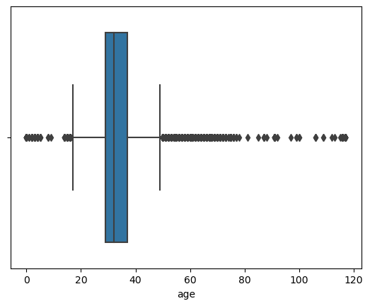

```python
sns.boxplot(df['age'])
plt.show()
```

```python
Q1 = df['age'].quantile(0.25)
Q3 = df['age'].quantile(0.75)
IQR = Q3-Q1
print(Q1)
print(Q3)
print(IQR)
```

```
29.0
37.0
8.0
```

```python
lower_whisker  = Q1-(1.5*IQR)
upper_whisker  = Q3+(1.5*IQR)
print(lower_whisker)
print(upper_whisker)
```

```
17.0
49.0
```

```python
df_out = df.loc[(df['age'] < upper_whisker) & (df['age'] > lower_whisker)]
```

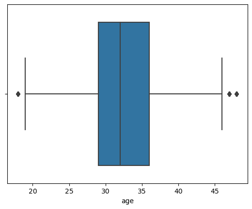

```python
sns.boxplot(df_out['age'])
plt.show()
```

### 11. Check the distribution of the different categories in the column 'rented for' using appropriate plot

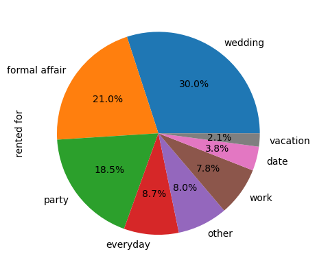

```python
df['rented for'].value_counts().plot(kind='pie',autopct='%1.1f%%')
plt.show()
```

## PART 3. Data Preparation for model building:

## 12. Encode the categorical variables in the dataset.

```python
df1=df.copy()
```

```python
df1.select_dtypes('object').columns
```

```
Index(['fit', 'bust size', 'rented for', 'body type', 'category'], dtype='object')
```

```python
for col in df1.select_dtypes('object').columns:
    le=LabelEncoder()
    df1[col]=le.fit_transform(df1[col])
```

```python
df1
```

|  | fit | bust size | weight | rating | rented for | body type | category | height | size | age |
| --- | --- | --- | --- | --- | --- | --- | --- | --- | --- | --- |
| 0 | 0 | 39 | 137.0 | 10.0 | 5 | 3 | 44 | 68.0 | 14 | 28.0 |
| 1 | 0 | 37 | 132.0 | 10.0 | 3 | 6 | 20 | 66.0 | 12 | 36.0 |
| 2 | 0 | 37 | 135.0 | 10.0 | 4 | 3 | 45 | 64.0 | 4 | 116.0 |
| 3 | 0 | 38 | 135.0 | 8.0 | 2 | 4 | 16 | 65.0 | 8 | 34.0 |
| 4 | 0 | 37 | 145.0 | 10.0 | 6 | 1 | 20 | 69.0 | 12 | 27.0 |
| ... | ... | ... | ... | ... | ... | ... | ... | ... | ... | ... |
| 192539 | 0 | 41 | 140.0 | 10.0 | 7 | 3 | 26 | 69.0 | 8 | 42.0 |
| 192540 | 0 | 25 | 100.0 | 10.0 | 7 | 5 | 16 | 61.0 | 4 | 29.0 |
| 192541 | 0 | 48 | 135.0 | 6.0 | 1 | 6 | 16 | 68.0 | 8 | 31.0 |
| 192542 | 0 | 51 | 165.0 | 10.0 | 6 | 4 | 16 | 66.0 | 16 | 31.0 |
| 192543 | 0 | 50 | 155.0 | 10.0 | 6 | 1 | 20 | 66.0 | 16 | 30.0 |

192544 rows × 10 columns

### 13. Standardize the data, so that the values are within a particular range.

```python
ds=df1.select_dtypes(include=['int64','float64'])
scaler = StandardScaler()
scaler.fit(ds)
standized_data =pd.DataFrame(scaler.transform(ds),columns=ds.columns)
```

```python
standized_data.head()
```

|  | fit | bust size | weight | rating | rented for | body type | category | height | size | age |
| --- | --- | --- | --- | --- | --- | --- | --- | --- | --- | --- |
| 0 | -0.556291 | -0.004640 | -0.000957 | 0.634498 | 0.514420 | 0.020953 | 1.569310 | 1.011893 | 0.206575 | -0.729154 |
| 1 | -0.556291 | -0.187210 | -0.249202 | 0.634498 | -0.456753 | 1.927582 | -0.307247 | 0.259688 | -0.028862 | 0.265991 |
| 2 | -0.556291 | -0.187210 | -0.100255 | 0.634498 | 0.028833 | 0.020953 | 1.647500 | -0.492517 | -0.970608 | 10.217442 |
| 3 | -0.556291 | -0.095925 | -0.100255 | -0.764242 | -0.942340 | 0.656496 | -0.620006 | -0.116415 | -0.499735 | 0.017205 |
| 4 | -0.556291 | -0.187210 | 0.396235 | 0.634498 | 1.000007 | -1.250132 | -0.307247 | 1.387995 | -0.028862 | -0.853547 |

## Principal Component Analysis and Clustering

### 14. Apply PCA on the above dataset and determine the number of PCA components to be used so that 90-95% of the variance in data is explained by the same

```python
## Calculating covariance matrix
cov_matrix = np.cov(standized_data.T)
print('Covariance matrix','\n',cov_matrix)
```

```
Covariance matrix
 [[ 1.00000519e+00  9.05525666e-03  1.36712983e-02 -2.45044635e-01
   8.35378787e-03 -7.61016810e-03  3.35892077e-04  1.44717645e-04
   6.54006939e-02  1.59721574e-03]
 [ 9.05525666e-03  1.00000519e+00  5.68663389e-01 -2.09457651e-02
  -2.07814670e-03 -2.15702411e-01 -1.09647683e-02  1.47036167e-01
   6.27115858e-01  1.65476458e-01]
 [ 1.36712983e-02  5.68663389e-01  1.00000519e+00 -2.08485232e-02
   9.70156108e-03 -2.34400313e-01 -1.44172746e-02  3.49055850e-01
   7.23391050e-01  6.29822084e-02]
 [-2.45044635e-01 -2.09457651e-02 -2.08485232e-02  1.00000519e+00
   1.27900970e-02  4.72965534e-03 -2.37071846e-02  1.74835660e-03
  -3.67286881e-02 -3.51310734e-02]
 [ 8.35378787e-03 -2.07814670e-03  9.70156108e-03  1.27900970e-02
   1.00000519e+00 -9.08626233e-03 -5.76351186e-02 -1.70706029e-02
   4.87422452e-03 -3.82507449e-02]
 [-7.61016810e-03 -2.15702411e-01 -2.34400313e-01  4.72965534e-03
  -9.08626233e-03  1.00000519e+00 -1.85295641e-03 -1.33577071e-01
  -2.14155816e-01 -4.17804903e-02]
 [ 3.35892077e-04 -1.09647683e-02 -1.44172746e-02 -2.37071846e-02
  -5.76351186e-02 -1.85295641e-03  1.00000519e+00 -4.34401436e-03
  -5.62602705e-03  2.45069570e-02]
 [ 1.44717645e-04  1.47036167e-01  3.49055850e-01  1.74835660e-03
  -1.70706029e-02 -1.33577071e-01 -4.34401436e-03  1.00000519e+00
   2.28425433e-01 -7.28094995e-03]
 [ 6.54006939e-02  6.27115858e-01  7.23391050e-01 -3.67286881e-02
   4.87422452e-03 -2.14155816e-01 -5.62602705e-03  2.28425433e-01
   1.00000519e+00  1.55120227e-01]
 [ 1.59721574e-03  1.65476458e-01  6.29822084e-02 -3.51310734e-02
  -3.82507449e-02 -4.17804903e-02  2.45069570e-02 -7.28094995e-03
   1.55120227e-01  1.00000519e+00]]
```

```python
## Calculating eigen values and eigen vectors
eig_vals, eig_vecs = np.linalg.eig(cov_matrix)
print('Eigen vectors:','\n',eig_vecs)
print('\n')
print('Eigen values:','\n',eig_vals)
```

```
Eigen vectors:
 [[-3.79182406e-02 -5.21339725e-02  3.73184198e-02 -6.88434588e-01
  -6.93932057e-01  1.76424493e-01 -5.38601361e-02  6.33233638e-02
  -3.03727146e-02  2.97369220e-03]
 [-4.96913898e-01 -1.06638737e-01  7.89323759e-01  1.84310214e-02
   4.70940698e-02 -7.62941588e-02  1.83968543e-01  2.48180115e-01
   1.56953838e-02 -1.20872949e-01]
 [-5.43366077e-01 -6.70187842e-01 -4.54017747e-01  5.09818200e-02
   3.46047997e-02  7.31970933e-02 -8.00361572e-02  5.47991186e-02
  -1.11402528e-02 -1.75448454e-01]
 [ 3.64031019e-02 -7.04524838e-03  6.01937589e-04  7.00031122e-01
  -7.03930568e-01 -4.58063321e-02  4.05279947e-02  8.70339882e-02
   2.32987301e-02 -3.47061487e-02]
 [ 1.94047852e-04  2.65517065e-03  1.48403766e-02  4.65662187e-02
   2.69087466e-02  5.95847893e-01  3.74763049e-01 -2.22693417e-01
   6.69042233e-01 -6.47167696e-02]
 [ 2.54214421e-01 -1.92370737e-02  2.76410781e-02 -4.84620878e-02
  -6.13850242e-04 -6.32829507e-02  1.41897827e-01 -1.49609530e-01
  -1.59830054e-01 -9.27266736e-01]
 [ 8.28640768e-03 -6.21298550e-03  6.76633329e-03 -9.29863376e-02
  -4.60785449e-02 -5.49109526e-01 -3.98043909e-01  2.00040328e-02
   7.13111284e-01 -1.42088601e-01]
 [-2.71344343e-01  1.10132087e-01  2.12596292e-01  9.63048660e-02
  -5.43547512e-02  1.76807075e-01 -5.16393599e-01 -7.36531005e-01
  -1.25466543e-01 -2.59626083e-02]
 [-5.46084895e-01  7.20632984e-01 -3.42083443e-01 -1.95930931e-02
  -2.12737937e-02 -1.61608807e-02  8.53606225e-02  1.50972381e-01
   6.03532338e-03 -1.85054451e-01]
 [-1.36149797e-01 -6.96574442e-02 -7.87054472e-02 -1.01259249e-01
  -1.15195527e-01 -5.13337057e-01  6.01860683e-01 -5.34951224e-01
  -2.63643648e-02  1.85132311e-01]]


Eigen values:
 [2.54938767 0.25577858 0.41695454 1.24894331 0.75210664 1.08478886
 1.01807319 0.83998391 0.9453528  0.88868245]
```

```python
## Calculating the Variance explained and the cummulative variance explained
total = sum(eig_vals)
var_exp = [ (i/total)*100  for i in sorted(eig_vals,reverse=True)]
cum_var_exp = np.cumsum(var_exp)
print('Variance Explained: ',var_exp)
print('\n')
print('Cummulative Variance Explained: ',cum_var_exp)
```

```
Variance Explained:  [25.493744303499692, 12.489368205336838, 10.847832273773134, 10.180678986925312, 9.453478874770498, 8.886778360335555, 8.399795477769086, 7.521027307046048, 4.169523708096742, 2.5577725024471025]


Cummulative Variance Explained:  [ 25.4937443   37.98311251  48.83094478  59.01162377  68.46510264
  77.351881    85.75167648  93.27270379  97.4422275  100.        ]
```

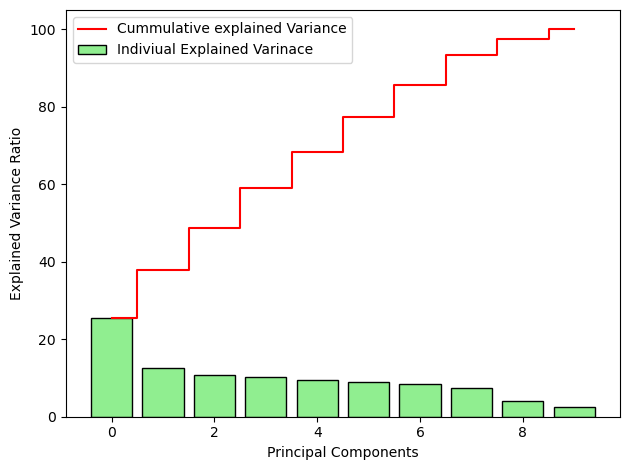

```python
## Scree plot
plt.bar(range(10),var_exp, align='center',color='lightgreen',edgecolor='black',label='Indiviual Explained Varinace')
plt.step(range(10), cum_var_exp, where='mid',color='red',label='Cummulative explained Variance')
plt.legend(loc = 'best')
plt.ylabel('Explained Variance Ratio')
plt.xlabel('Principal Components')
plt.tight_layout()
plt.show()
```

### 15. Apply K-means clustering and segment the data. (You may use original data or PCA transformed data)

a. Find the optimal K Value using elbow plot for K Means clustering.

b. Build a Kmeans clustering model using the obtained optimal K value from the elbow plot.

c. Compute silhouette score for evaluating the quality of the K Means clustering technique.

```python
## Fitting the PCA model
pca=PCA(n_components = 8)
pca.fit(standized_data)
```

```
PCA(n_components=8)
```

```python
data_pca = pca.transform(standized_data)
data_pca = pd.DataFrame(data_pca,columns=['PC1','PC2','PC3', 'PC4', 'PC5', 'PC6', 'PC7', 'PC8'])
data_pca.head()
```

|  | PC1 | PC2 | PC3 | PC4 | PC5 | PC6 | PC7 | PC8 |
| --- | --- | --- | --- | --- | --- | --- | --- | --- |
| 0 | 0.222657 | -0.871255 | 0.133583 | -1.317746 | 1.385041 | 0.498137 | 0.391549 | -0.094749 |
| 1 | -0.669093 | -0.723509 | 0.446753 | 0.289349 | -0.841026 | 1.623649 | 0.570854 | -0.121513 |
| 2 | 0.516748 | 0.397317 | 6.325453 | 5.708219 | 1.007211 | -1.845138 | 5.258172 | -1.277636 |
| 3 | -0.559129 | 0.180109 | 0.347079 | 0.003970 | -1.167688 | 0.306926 | 0.030717 | 0.933800 |
| 4 | 0.642889 | -1.200274 | -1.443786 | -0.923737 | 0.522263 | -0.878866 | 0.616614 | 0.009609 |

```python
cluster_range = range(1,15)
cluster_errors = []

for num_clusters in cluster_range:

    clusters = KMeans(num_clusters, n_init=10)
    clusters.fit(data_pca)

    labels = clusters.labels_
    centroids = clusters.cluster_centers_

    cluster_errors.append(clusters.inertia_)

clusters_df = pd.DataFrame({'num_clusters':cluster_range,
                           'cluster_errors':cluster_errors})

clusters_df
```

|  | num_clusters | cluster_errors |
| --- | --- | --- |
| 0 | 1 | 1.795910e+06 |
| 1 | 2 | 1.496414e+06 |
| 2 | 3 | 1.358291e+06 |
| 3 | 4 | 1.248765e+06 |
| 4 | 5 | 1.154887e+06 |
| 5 | 6 | 1.092697e+06 |
| 6 | 7 | 1.038090e+06 |
| 7 | 8 | 9.866183e+05 |
| 8 | 9 | 9.527628e+05 |
| 9 | 10 | 9.239020e+05 |
| 10 | 11 | 9.000879e+05 |
| 11 | 12 | 8.743142e+05 |
| 12 | 13 | 8.525427e+05 |
| 13 | 14 | 8.390428e+05 |

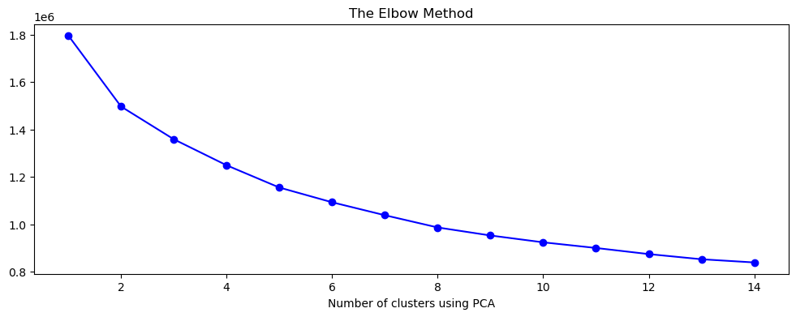

```python
# Elbow method
plt.figure(figsize=[12,4])

plt.title('The Elbow Method')
plt.xlabel('Number of clusters using PCA')
plt.plot(clusters_df['num_clusters'],clusters_df['cluster_errors'],marker='o',color='b')
plt.show()
```

```python
## Fit the KMeans clustering model using the obtained optimal K
kmeans = KMeans(n_clusters=2, n_init=15, random_state=2345)
kmeans.fit(data_pca)
```

```
KMeans(n_clusters=2, n_init=15, random_state=2345)
```

```python
## obtained labels from kmeans clustering
kmeans.labels_
```

```
array([0, 0, 1, ..., 0, 1, 1], dtype=int32)
```

```python
## Creating a new dataframe only for labels.
df_labels = pd.DataFrame(kmeans.labels_, columns=list(['Labels']))
kmeans_df=data_pca.join(df_labels)
kmeans_df.head(5)
```

|  | PC1 | PC2 | PC3 | PC4 | PC5 | PC6 | PC7 | PC8 | Labels |
| --- | --- | --- | --- | --- | --- | --- | --- | --- | --- |
| 0 | 0.222657 | -0.871255 | 0.133583 | -1.317746 | 1.385041 | 0.498137 | 0.391549 | -0.094749 | 0 |
| 1 | -0.669093 | -0.723509 | 0.446753 | 0.289349 | -0.841026 | 1.623649 | 0.570854 | -0.121513 | 0 |
| 2 | 0.516748 | 0.397317 | 6.325453 | 5.708219 | 1.007211 | -1.845138 | 5.258172 | -1.277636 | 1 |
| 3 | -0.559129 | 0.180109 | 0.347079 | 0.003970 | -1.167688 | 0.306926 | 0.030717 | 0.933800 | 0 |
| 4 | 0.642889 | -1.200274 | -1.443786 | -0.923737 | 0.522263 | -0.878866 | 0.616614 | 0.009609 | 1 |

```python
kmeans_df['Labels'].value_counts()
```

```
0    116793
1     75751
Name: Labels, dtype: int64
```

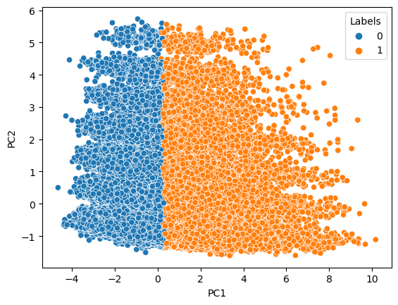

```python
## visalizing the clusters formed

sns.scatterplot(kmeans_df['PC1'], kmeans_df['PC2'], hue='Labels', data=kmeans_df)
plt.show()
```

```python
from sklearn.metrics import silhouette_score
kmeans_score = []

for i in range(2,9):
    kmeans = KMeans(n_clusters=i)
    kmeans = kmeans.fit(data_pca)
    labels = kmeans.predict(data_pca)
    print(i,silhouette_score(data_pca,labels))
```

```
2 0.16189540820931725
3 0.16327150083105627
4 0.15875059869401126
5 0.13521506711070785
6 0.13697087320205578
7 0.1423124469100614
8 0.13052590318030882
```

- As per elbow method optimal value of k seems to be 2
- As per silhouette score seems to be 3.

### 16. Apply Agglomerative clustering and segment the data. (You may use original data or PCA transformed data)

```python
data_pca_frac = data_pca.sample(frac=0.10)
```

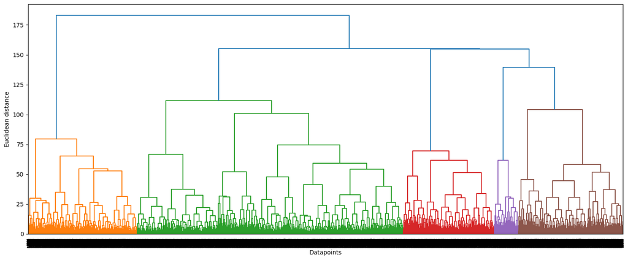

```python
plt.figure(figsize=[18,7])
merg = linkage(data_pca_frac, method='ward')
dendrogram(merg, leaf_rotation=90,)
plt.xlabel('Datapoints')
plt.ylabel('Euclidean distance')
plt.show()
```

```python
## Building hierarchical clustering model using the optimal clusters as 5
hie_cluster = AgglomerativeClustering(n_clusters=5, affinity='euclidean',
                                     linkage='ward')
hie_cluster_model = hie_cluster.fit(data_pca_frac)
```

```python
## Creating a dataframe of the labels
df_label1 = pd.DataFrame(hie_cluster_model.labels_,columns=['Labels'])
df_label1.head(5)
```

|  | Labels |
| --- | --- |
| 0 | 0 |
| 1 | 1 |
| 2 | 0 |
| 3 | 4 |
| 4 | 2 |

```python
# Computing silhouette score

for i in range(2,9):
    hier = AgglomerativeClustering(n_clusters=i)
    hier = hier.fit(data_pca_frac)
    labels = hier.fit_predict(data_pca_frac)
    print(i,silhouette_score(data_pca_frac,labels))
```

```
2 0.09838082081034666
3 0.08617438428893469
4 0.11025957627741945
5 0.11716721881473004
6 0.054027914115293375
7 0.06355469392423457
8 0.06871812655993202
```

- Silhouette score is highest for 5

### Conclusion

```python
## joining the label dataframe with unscaled initial cleaned dataframe.

df_hier = df.join(df_label1)
df_hier.head()
```

|  | fit | bust size | weight | rating | rented for | body type | category | height | size | age | Labels |
| --- | --- | --- | --- | --- | --- | --- | --- | --- | --- | --- | --- |
| 0 | fit | 34d | 137.0 | 10.0 | vacation | hourglass | romper | 68.0 | 14 | 28.0 | 0.0 |
| 1 | fit | 34b | 132.0 | 10.0 | other | straight & narrow | gown | 66.0 | 12 | 36.0 | 1.0 |
| 2 | fit | 34b | 135.0 | 10.0 | party | hourglass | sheath | 64.0 | 4 | 116.0 | 0.0 |
| 3 | fit | 34c | 135.0 | 8.0 | formal affair | pear | dress | 65.0 | 8 | 34.0 | 4.0 |
| 4 | fit | 34b | 145.0 | 10.0 | wedding | athletic | gown | 69.0 | 12 | 27.0 | 2.0 |

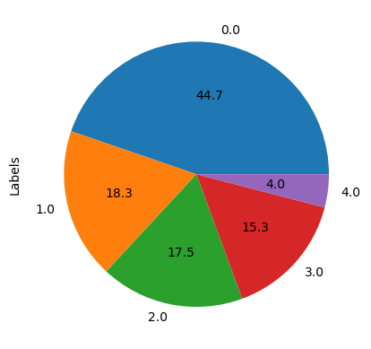

```python
df_hier['Labels'].value_counts().plot(kind='pie',autopct='%0.1f')
plt.show()
```

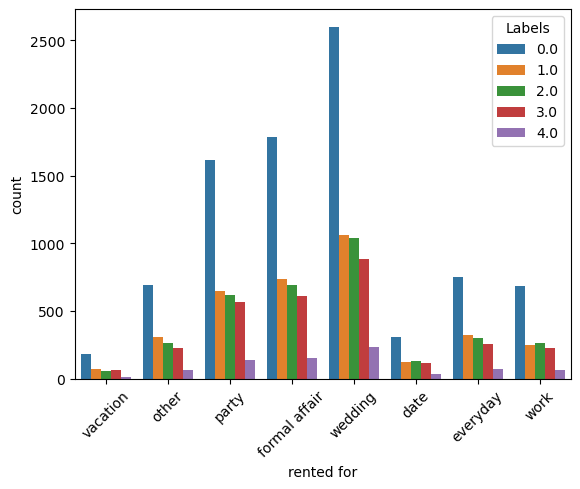

```python
# Bivariate using rented for column

sns.countplot(df_hier['rented for'],hue='Labels',data=df_hier)
plt.xticks(rotation = 45)
plt.show()
```

- Maximum clothes have been rented for wedding event in most of the clusters

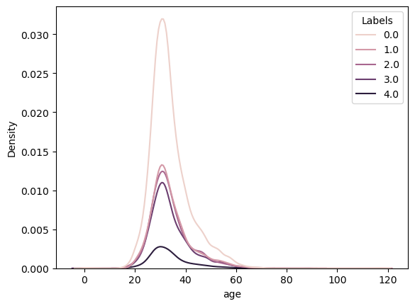

```python
## Checking the age distribution of the different clusters.
sns.kdeplot(df_hier['age'],hue='Labels',data=df_hier)
plt.show()
```

- Age distribution is same amongst all clusters
- People with age around 30 have rented most

## Happy Learning:)